# Tayko Software Cataloger

Raghav Arora

2023-05-07

##Assignment of Tayko

```r
Tayko.com <- read.csv("Tayko.csv",header=TRUE)
head(Tayko.com)
```

```
##   sequence_number US source_a source_c source_b source_d source_e source_m
## 1               1  1        0        0        1        0        0        0
## 2               2  1        0        0        0        0        1        0
## 3               3  1        0        0        0        0        0        0
## 4               4  1        0        1        0        0        0        0
## 5               5  1        0        1        0        0        0        0
## 6               6  1        0        0        0        0        0        0
##   source_o source_h source_r source_s source_t source_u source_p source_x
## 1        0        0        0        0        0        0        0        0
## 2        0        0        0        0        0        0        0        0
## 3        0        0        0        0        1        0        0        0
## 4        0        0        0        0        0        0        0        0
## 5        0        0        0        0        0        0        0        0
## 6        0        0        1        0        0        0        0        0
##   source_w Freq last_update_days_ago X1st_update_days_ago Web.order Gender.male
## 1        0    2                 3662                 3662         1           0
## 2        0    0                 2900                 2900         1           1
## 3        0    2                 3883                 3914         0           0
## 4        0    1                  829                  829         0           1
## 5        0    1                  869                  869         0           0
## 6        0    1                 1995                 2002         0           0
##   Address_is_res Purchase Spending
## 1              1        1      128
## 2              0        0        0
## 3              0        1      127
## 4              0        0        0
## 5              0        0        0
## 6              1        0        0
```

```r
dim(Tayko.com)
```

```
## [1] 2000   25
```

1. Each catalog costs approximately $2 to mail (including printing, postage, and mailing costs). Estimate the gross profit that the firm could expect from the remaining 180,000 names if it selects them randomly from the pool.

```r
#gross_profit <- cost_per_mail * response_rate * average_spend * number_of_left_entries
cost_per_mail <- 2
response_rate <- 0.053
number_of_left_entries <- 180000
average_spend <- mean(Tayko.com[Tayko.com$Purchase==1,]$Spending)
gross_profit <- (average_spend * response_rate - cost_per_mail) * number_of_left_entries
gross_profit
```

```
## [1] 1598075
```

2. Develop a model for classifying a customer as a purchaser or non-purchaser.
1. Partition the data randomly into a training set (800 records), validation set (700 records), and test set (500 records).

```r
#Droped last_update_days_ago & 1st_update_days_ago but kept sequence_number required as purchaseID
Tayko.com <- Tayko.com[,-c(19,20)]
set.seed(1)
train_rows <- sample(rownames(Tayko.com),dim(Tayko.com)[1]*0.4)
valid_rows <- sample(setdiff(rownames(Tayko.com),train_rows),dim(Tayko.com)[1]*0.35)
test_rows <- setdiff(rownames(Tayko.com),union(train_rows,valid_rows))
train.data <- Tayko.com[train_rows,] # 800
valid.data <- Tayko.com[valid_rows,] # 700
test.data <- Tayko.com[test_rows,] # 500
```

2. Run step-wise logistic regression using backward elimination to select the best subset of variables, then use this model to classify the data into purchasers and non-purchasers. Use only the training set for running the model. (Logistic regression is used because it yields an estimated “probability of purchase,” which is required later in the analysis.)

```r
#Drop spending from variables
lr_model <- glm(Purchase ~ .-Spending, data = train.data, family = binomial);
lr_model_b <- step(lr_model, direction = "backward");
```

```
## Start:  AIC=662.64
## Purchase ~ (sequence_number + US + source_a + source_c + source_b +
##     source_d + source_e + source_m + source_o + source_h + source_r +
##     source_s + source_t + source_u + source_p + source_x + source_w +
##     Freq + Web.order + Gender.male + Address_is_res + Spending) -
##     Spending
```

[output not shown]

```
##                   Df Deviance    AIC
## - source_c         1   618.64 660.64
## - source_b         1   618.70 660.70
## - source_o         1   618.72 660.72
## - source_t         1   619.17 661.17
## - US               1   619.26 661.26
## - source_d         1   619.32 661.32
## - source_m         1   619.43 661.43
## - Gender.male      1   619.47 661.47
## - sequence_number  1   619.57 661.57
## - source_r         1   619.68 661.68
## - source_e         1   620.56 662.56
## <none>                 618.64 662.64
## - source_x         1   621.51 663.51
## - source_s         1   621.57 663.57
## - source_p         1   622.07 664.07
## - source_w         1   622.25 664.25
## - source_a         1   624.75 666.75
## - Address_is_res   1   627.18 669.18
## - source_h         1   627.30 669.30
## - source_u         1   628.97 670.97
## - Web.order        1   649.76 691.76
## - Freq             1   948.80 990.80
```

```
##
## Step:  AIC=660.64
## Purchase ~ sequence_number + US + source_a + source_b + source_d +
##     source_e + source_m + source_o + source_h + source_r + source_s +
##     source_t + source_u + source_p + source_x + source_w + Freq +
##     Web.order + Gender.male + Address_is_res
```

[output not shown]

```
##                   Df Deviance    AIC
## - source_o         1   618.75 658.75
## - source_b         1   618.77 658.77
## - US               1   619.26 659.26
## - Gender.male      1   619.47 659.47
## - sequence_number  1   619.57 659.57
## - source_t         1   619.59 659.59
## - source_d         1   619.83 659.83
## - source_m         1   619.83 659.83
## <none>                 618.64 660.64
## - source_r         1   621.10 661.10
## - source_x         1   622.73 662.73
## - source_p         1   623.18 663.18
## - source_e         1   623.85 663.85
## - source_s         1   624.68 664.68
## - Address_is_res   1   627.18 667.18
## - source_w         1   628.43 668.43
## - source_a         1   634.31 674.31
## - source_h         1   638.09 678.09
## - source_u         1   644.86 684.86
## - Web.order        1   649.79 689.79
## - Freq             1   950.65 990.65
```

```
##
## Step:  AIC=658.75
## Purchase ~ sequence_number + US + source_a + source_b + source_d +
##     source_e + source_m + source_h + source_r + source_s + source_t +
##     source_u + source_p + source_x + source_w + Freq + Web.order +
##     Gender.male + Address_is_res
```

[output not shown]

```
##                   Df Deviance    AIC
## - source_b         1   618.93 656.93
## - US               1   619.36 657.36
## - Gender.male      1   619.56 657.56
## - source_t         1   619.62 657.62
## - sequence_number  1   619.62 657.62
## - source_m         1   619.86 657.86
## - source_d         1   620.07 658.07
## <none>                 618.75 658.75
## - source_r         1   621.10 659.10
## - source_x         1   622.74 660.74
## - source_p         1   623.18 661.18
## - source_e         1   623.95 661.95
## - source_s         1   624.73 662.73
## - Address_is_res   1   627.31 665.31
## - source_w         1   628.78 666.78
## - source_a         1   634.88 672.88
## - source_h         1   639.54 677.54
## - source_u         1   646.13 684.13
## - Web.order        1   649.85 687.85
## - Freq             1   951.50 989.50
```

```
##
## Step:  AIC=656.93
## Purchase ~ sequence_number + US + source_a + source_d + source_e +
##     source_m + source_h + source_r + source_s + source_t + source_u +
##     source_p + source_x + source_w + Freq + Web.order + Gender.male +
##     Address_is_res
```

[output not shown]

```
##                   Df Deviance    AIC
## - US               1   619.58 655.58
## - Gender.male      1   619.68 655.68
## - sequence_number  1   619.83 655.83
## - source_d         1   620.09 656.09
## - source_t         1   620.13 656.13
## - source_m         1   620.30 656.30
## <none>                 618.93 656.93
## - source_r         1   622.23 658.23
## - source_x         1   623.42 659.42
## - source_p         1   623.88 659.88
## - source_s         1   626.32 662.32
## - source_e         1   626.35 662.35
## - Address_is_res   1   627.43 663.43
## - source_w         1   632.96 668.96
## - source_a         1   639.96 675.96
## - source_h         1   641.05 677.05
## - Web.order        1   650.14 686.14
## - source_u         1   654.30 690.30
## - Freq             1   951.51 987.51
```

```
##
## Step:  AIC=655.58
## Purchase ~ sequence_number + source_a + source_d + source_e +
##     source_m + source_h + source_r + source_s + source_t + source_u +
##     source_p + source_x + source_w + Freq + Web.order + Gender.male +
##     Address_is_res
```

[output not shown]

```
##                   Df Deviance    AIC
## - Gender.male      1   620.38 654.38
## - sequence_number  1   620.59 654.59
## - source_t         1   620.65 654.65
## - source_d         1   620.71 654.71
## - source_m         1   621.00 655.00
## <none>                 619.58 655.58
## - source_r         1   622.90 656.90
## - source_x         1   624.17 658.17
## - source_p         1   624.39 658.39
## - source_e         1   626.49 660.49
## - source_s         1   627.23 661.23
## - Address_is_res   1   627.83 661.83
## - source_w         1   633.02 667.02
## - source_a         1   640.67 674.67
## - source_h         1   642.08 676.08
## - Web.order        1   650.73 684.73
## - source_u         1   654.35 688.35
## - Freq             1   954.60 988.60
```

```
##
## Step:  AIC=654.38
## Purchase ~ sequence_number + source_a + source_d + source_e +
##     source_m + source_h + source_r + source_s + source_t + source_u +
##     source_p + source_x + source_w + Freq + Web.order + Address_is_res
```

```
##                   Df Deviance    AIC
## - sequence_number  1   621.37 653.37
## - source_t         1   621.38 653.38
## - source_d         1   621.44 653.44
## - source_m         1   621.70 653.70
## <none>                 620.38 654.38
## - source_r         1   623.72 655.72
## - source_x         1   624.93 656.93
## - source_p         1   625.45 657.45
## - source_e         1   627.24 659.24
## - source_s         1   627.80 659.80
## - Address_is_res   1   628.41 660.41
## - source_w         1   633.82 665.82
## - source_a         1   641.54 673.54
## - source_h         1   642.67 674.67
## - Web.order        1   651.45 683.45
## - source_u         1   654.90 686.90
## - Freq             1   955.41 987.41
```

```
##
## Step:  AIC=653.37
## Purchase ~ source_a + source_d + source_e + source_m + source_h +
##     source_r + source_s + source_t + source_u + source_p + source_x +
##     source_w + Freq + Web.order + Address_is_res
```

```
##                  Df Deviance    AIC
## - source_d        1   622.36 652.36
## - source_t        1   622.48 652.48
## - source_m        1   622.78 652.78
## <none>                621.37 653.37
## - source_r        1   624.63 654.63
## - source_x        1   625.86 655.86
## - source_p        1   626.45 656.45
## - source_e        1   628.27 658.27
## - source_s        1   628.64 658.64
## - Address_is_res  1   629.61 659.61
## - source_w        1   634.64 664.64
## - source_a        1   642.74 672.74
## - source_h        1   643.48 673.48
## - Web.order       1   651.54 681.54
## - source_u        1   656.43 686.43
## - Freq            1   957.00 987.00
```

```
##
## Step:  AIC=652.36
## Purchase ~ source_a + source_e + source_m + source_h + source_r +
##     source_s + source_t + source_u + source_p + source_x + source_w +
##     Freq + Web.order + Address_is_res
```

```
##                  Df Deviance    AIC
## - source_t        1   623.89 651.89
## - source_m        1   624.12 652.12
## <none>                622.36 652.36
## - source_r        1   626.66 654.66
## - source_x        1   627.34 655.34
## - source_p        1   627.99 655.99
## - Address_is_res  1   630.34 658.34
## - source_s        1   630.91 658.91
## - source_e        1   631.29 659.29
## - source_w        1   638.90 666.90
## - source_h        1   643.48 671.48
## - source_a        1   647.65 675.65
## - Web.order       1   652.78 680.78
## - source_u        1   663.04 691.04
## - Freq            1   957.10 985.10
```

```
##
## Step:  AIC=651.89
## Purchase ~ source_a + source_e + source_m + source_h + source_r +
##     source_s + source_u + source_p + source_x + source_w + Freq +
##     Web.order + Address_is_res
```

```
##                  Df Deviance    AIC
## - source_m        1   625.28 651.28
## <none>                623.89 651.89
## - source_r        1   627.27 653.27
## - source_x        1   628.30 654.30
## - source_p        1   628.97 654.97
## - source_s        1   631.38 657.38
## - source_e        1   631.49 657.49
## - Address_is_res  1   631.62 657.62
## - source_w        1   638.91 664.91
## - source_a        1   647.66 673.66
## - source_h        1   648.67 674.67
## - Web.order       1   655.57 681.57
## - source_u        1   663.24 689.24
## - Freq            1   961.57 987.57
```

```
##
## Step:  AIC=651.28
## Purchase ~ source_a + source_e + source_h + source_r + source_s +
##     source_u + source_p + source_x + source_w + Freq + Web.order +
##     Address_is_res
```

```
##                  Df Deviance    AIC
## <none>                625.28 651.28
## - source_r        1   628.08 652.08
## - source_x        1   629.35 653.35
## - source_p        1   630.04 654.04
## - source_e        1   631.95 655.95
## - source_s        1   632.10 656.10
## - Address_is_res  1   632.73 656.73
## - source_w        1   639.08 663.08
## - source_a        1   647.76 671.76
## - source_h        1   652.60 676.60
## - Web.order       1   656.45 680.45
## - source_u        1   663.24 687.24
## - Freq            1   964.69 988.69
```

```r
library(caret)
summary(lr_model_b)
```

```
##
## Call:
## glm(formula = Purchase ~ source_a + source_e + source_h + source_r +
##     source_s + source_u + source_p + source_x + source_w + Freq +
##     Web.order + Address_is_res, family = binomial, data = train.data)
##
## Deviance Residuals:
##     Min       1Q   Median       3Q      Max
## -3.4657  -0.5538  -0.1717   0.6083   2.2843
##
## Coefficients:
##                Estimate Std. Error z value Pr(>|z|)
## (Intercept)     -4.0812     0.3519 -11.599  < 2e-16 ***
## source_a         1.6844     0.3657   4.606 4.11e-06 ***
## source_e         0.8689     0.3376   2.574 0.010051 *
## source_h        -2.8871     0.6357  -4.542 5.58e-06 ***
## source_r         0.7035     0.4187   1.680 0.092908 .
## source_s         1.2393     0.4668   2.655 0.007931 **
## source_u         2.1005     0.3588   5.854 4.81e-09 ***
## source_p         2.2378     1.1745   1.905 0.056743 .
## source_x         1.6178     0.7757   2.086 0.037023 *
## source_w         1.1635     0.3175   3.664 0.000248 ***
## Freq             2.2837     0.1925  11.862  < 2e-16 ***
## Web.order        1.1071     0.2028   5.459 4.79e-08 ***
## Address_is_res  -0.7349     0.2718  -2.704 0.006843 **
## ---
## Signif. codes:  0 '***' 0.001 '**' 0.01 '*' 0.05 '.' 0.1 ' ' 1
##
## (Dispersion parameter for binomial family taken to be 1)
##
##     Null deviance: 1108.96  on 799  degrees of freedom
## Residual deviance:  625.28  on 787  degrees of freedom
## AIC: 651.28
##
## Number of Fisher Scoring iterations: 6
```

```r
prediction <- predict(lr_model_b, train.data, type = "response")
classification <- ifelse(prediction > 0.5, 1, 0)
confusionMatrix(factor(classification),factor(train.data$Purchase))
```

```
## Confusion Matrix and Statistics
##
##           Reference
## Prediction   0   1
##          0 334  73
##          1  70 323
##
##                Accuracy : 0.8212
##                  95% CI : (0.7929, 0.8472)
##     No Information Rate : 0.505
##     P-Value [Acc > NIR] : <2e-16
##
##                   Kappa : 0.6424
##
##  Mcnemar's Test P-Value : 0.8672
##
##             Sensitivity : 0.8267
##             Specificity : 0.8157
##          Pos Pred Value : 0.8206
##          Neg Pred Value : 0.8219
##              Prevalence : 0.5050
##          Detection Rate : 0.4175
##    Detection Prevalence : 0.5088
##       Balanced Accuracy : 0.8212
##
##        'Positive' Class : 0
##
```

3. Develop a model for predicting spending among the purchasers.
1. Create a vector of ID’s of only purchasers’ records (Purchase = 1).

```r
# Only include purchase
purchaser <- Tayko.com[Tayko.com$Purchase == 1, ]
purchaser_id <- purchaser$sequence_number
purchaser_id
```

[output not shown]

[output cut: 57 more lines]

2. Partition this dataset into the training and validation records. (Use the same training/validation labels from the earlier partitioning; one way is to use function intersect() to find IDs of purchasers in the original partitions).

```r
train_rows <- intersect(train.data$sequence_number, Tayko.com[Tayko.com$Purchase == 1, ]$sequence_number)
valid_rows <- intersect(valid.data$sequence_number, Tayko.com[Tayko.com$Purchase == 1, ]$sequence_number)
train.data <- Tayko.com[Tayko.com$sequence_number %in% train_rows, ]
valid.data <- Tayko.com[Tayko.com$sequence_number %in% valid_rows, ]
```

3. Develop models for predicting spending, using:
4. Multiple linear regression (use stepwise regression)

```r
lm_model <- lm(Spending ~ ., data = train.data)
lm_model <- step(lm_model)
```

```
## Start:  AIC=4102
## Spending ~ sequence_number + US + source_a + source_c + source_b +
##     source_d + source_e + source_m + source_o + source_h + source_r +
##     source_s + source_t + source_u + source_p + source_x + source_w +
##     Freq + Web.order + Gender.male + Address_is_res + Purchase
##
##
## Step:  AIC=4102
## Spending ~ sequence_number + US + source_a + source_c + source_b +
##     source_d + source_e + source_m + source_o + source_h + source_r +
##     source_s + source_t + source_u + source_p + source_x + source_w +
##     Freq + Web.order + Gender.male + Address_is_res
##
##                   Df Sum of Sq      RSS    AIC
## - source_t         1        10 11171639 4100.0
## - Gender.male      1        60 11171689 4100.0
## - sequence_number  1        94 11171723 4100.0
## - source_o         1       200 11171829 4100.0
## - source_x         1       697 11172326 4100.0
## - source_p         1      1036 11172665 4100.0
## - source_s         1      1056 11172685 4100.0
## - source_c         1      1590 11173219 4100.1
## - source_u         1      3958 11175587 4100.1
## - source_a         1      4985 11176614 4100.2
## - source_b         1      5703 11177333 4100.2
## - source_r         1      5855 11177484 4100.2
## - source_e         1      8478 11180108 4100.3
## - source_d         1      9069 11180698 4100.3
## - source_m         1     12556 11184185 4100.4
## - source_h         1     14090 11185719 4100.5
## - US               1     30257 11201886 4101.1
## - Web.order        1     31036 11202665 4101.1
## - source_w         1     50128 11221757 4101.8
## <none>                         11171629 4102.0
## - Address_is_res   1    415175 11586804 4114.4
## - Freq             1   9211419 20383048 4338.1
##
## Step:  AIC=4100
## Spending ~ sequence_number + US + source_a + source_c + source_b +
##     source_d + source_e + source_m + source_o + source_h + source_r +
```

[output cut: 321 more lines]

```
##                  Df Sum of Sq      RSS    AIC
## - source_m        1     49866 11456997 4076.0
## <none>                        11407131 4076.3
## - source_w        1    279801 11686932 4083.9
## - Address_is_res  1    397269 11804400 4087.8
## - Freq            1   9412055 20819186 4312.5
##
## Step:  AIC=4075.99
## Spending ~ source_w + Freq + Address_is_res
##
##                  Df Sum of Sq      RSS    AIC
## <none>                        11456997 4076.0
## - source_w        1    293517 11750514 4084.0
## - Address_is_res  1    396478 11853475 4087.5
## - Freq            1   9378299 20835296 4310.8
```

```r
lm_model <- lm(Spending ~ ., data = valid.data)
lm_model <- step(lm_model)
```

```
## Start:  AIC=3715.17
## Spending ~ sequence_number + US + source_a + source_c + source_b +
##     source_d + source_e + source_m + source_o + source_h + source_r +
##     source_s + source_t + source_u + source_p + source_x + source_w +
##     Freq + Web.order + Gender.male + Address_is_res + Purchase
##
##
## Step:  AIC=3715.17
## Spending ~ sequence_number + US + source_a + source_c + source_b +
##     source_d + source_e + source_m + source_o + source_h + source_r +
##     source_s + source_t + source_u + source_p + source_x + source_w +
##     Freq + Web.order + Gender.male + Address_is_res
##
##                   Df Sum of Sq      RSS    AIC
## - source_x         1        63  8956031 3713.2
## - source_h         1       289  8956256 3713.2
## - source_c         1       403  8956370 3713.2
## - source_t         1      1117  8957085 3713.2
## - US               1      2328  8958296 3713.3
## - source_s         1      5124  8961091 3713.4
## - source_p         1      5765  8961733 3713.4
## - source_e         1      5863  8961831 3713.4
## - source_d         1      8028  8963996 3713.5
## - source_m         1      9848  8965815 3713.6
## - source_o         1     18480  8974447 3713.9
## - Gender.male      1     18794  8974762 3713.9
## - source_b         1     20403  8976370 3714.0
## - source_w         1     24720  8980688 3714.2
## - Web.order        1     26869  8982837 3714.3
## - source_u         1     33473  8989440 3714.5
## - sequence_number  1     37305  8993273 3714.7
## - source_a         1     42415  8998383 3714.9
## <none>                          8955968 3715.2
## - source_r         1     89469  9045437 3716.8
## - Address_is_res   1    408448  9364416 3729.4
## - Freq             1   4939651 13895618 3872.6
##
## Step:  AIC=3713.18
## Spending ~ sequence_number + US + source_a + source_c + source_b +
##     source_d + source_e + source_m + source_o + source_h + source_r +
```

[output cut: 294 more lines]

```
## - Address_is_res  1    437501  9535146 3707.9
## - Freq            1   4970459 14068103 3849.1
##
## Step:  AIC=3692.01
## Spending ~ source_a + source_r + source_u + source_w + Freq +
##     Address_is_res
##
##                  Df Sum of Sq      RSS    AIC
## <none>                         9126112 3692.0
## - source_w        1     68461  9194574 3692.7
## - source_u        1    118458  9244570 3694.7
## - source_a        1    218222  9344334 3698.6
## - source_r        1    364657  9490769 3704.2
## - Address_is_res  1    441738  9567851 3707.2
## - Freq            1   4971763 14097876 3847.9
```

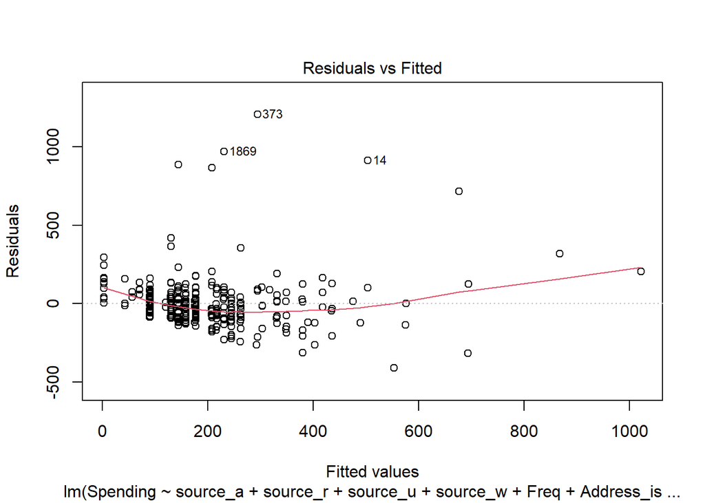

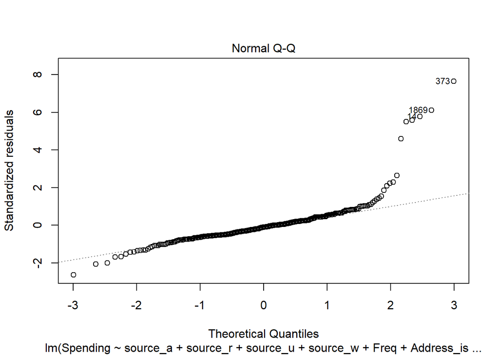

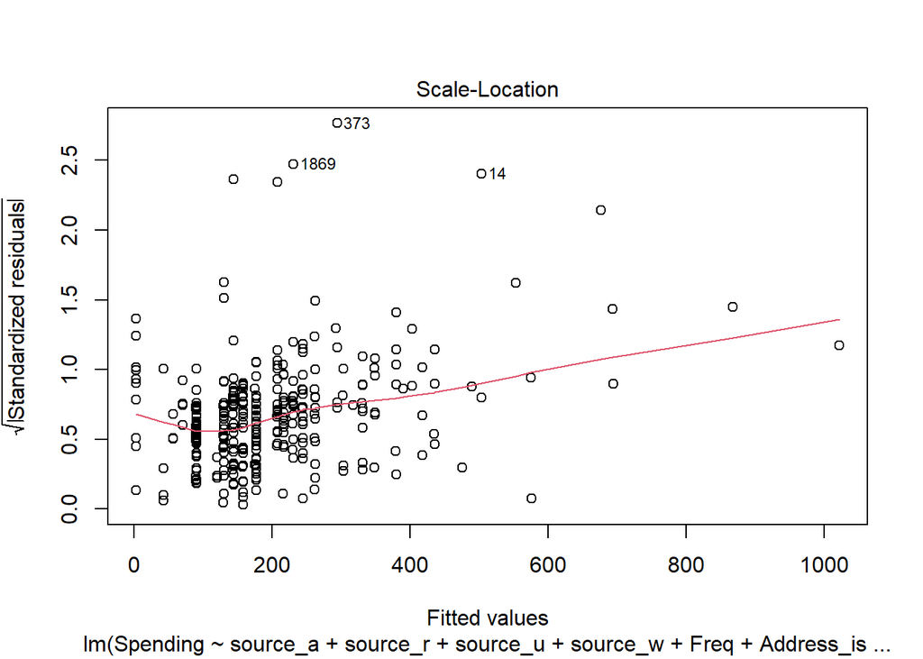

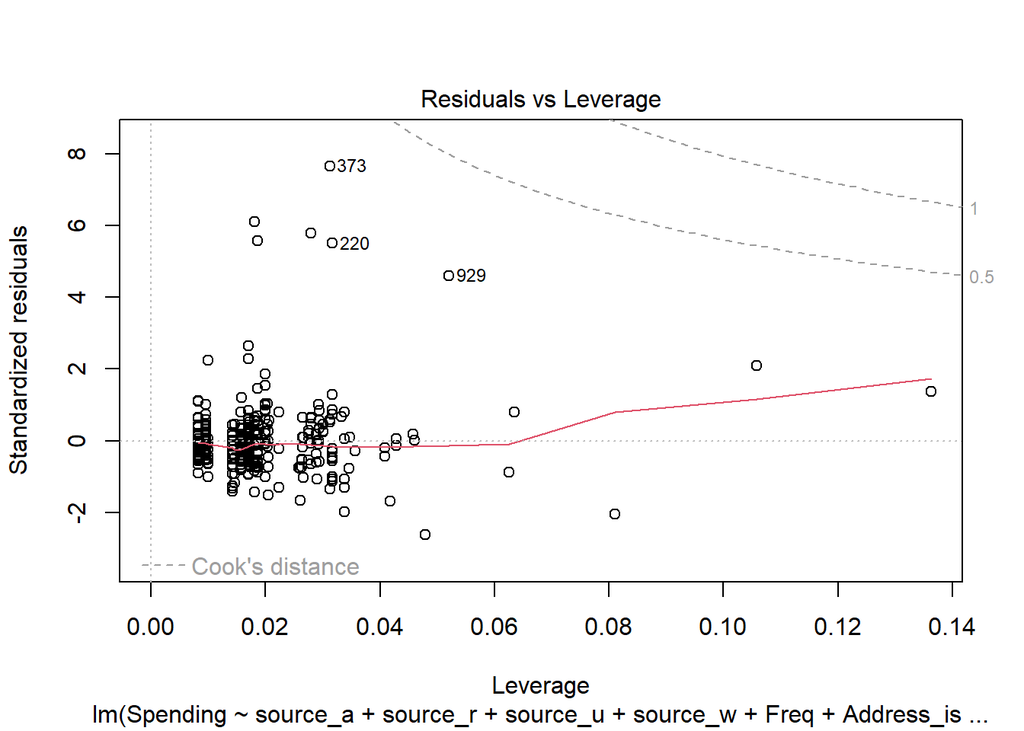

```r
# For the Presentation
plot(lm_model)
```

2. Regression trees

```r
library(rpart)
tree_model <- rpart(Spending ~ ., data = train.data)
tree_model
```

```
## n= 396
##
## node), split, n, deviance, yval
##       * denotes terminal node
##
##  1) root 396 20852660.0  218.1288
##    2) Freq< 7.5 389 13884290.0  201.5219
##      4) Freq< 2.5 279  3633912.0  147.5125 *
##      5) Freq>=2.5 110  7372329.0  338.5091
##       10) sequence_number>=493.5 86  4034302.0  312.3488
##         20) Freq< 3.5 46  2063335.0  244.1957 *
##         21) Freq>=3.5 40  1511590.0  390.7250 *
##       11) sequence_number< 493.5 24  3068276.0  432.2500
##         22) sequence_number< 362 15   373282.9  305.7333 *
##         23) sequence_number>=362 9  2054735.0  643.1111 *
##    3) Freq>=7.5 7   899246.0 1141.0000 *
```

```r
summary(tree_model)
```

```
## Call:
## rpart(formula = Spending ~ ., data = train.data)
##   n= 396
##
##           CP nsplit rel error    xerror      xstd
## 1 0.29104785      0 1.0000000 1.0036310 0.1905959
## 2 0.13801837      1 0.7089522 0.9749312 0.1799703
## 3 0.02188988      2 0.5709338 0.6932199 0.1240769
## 4 0.01000000      5 0.5052642 0.7440764 0.1353690
##
## Variable importance
##            Freq sequence_number        source_r        source_h       Web.order
##              87               9               1               1               1
##
## Node number 1: 396 observations,    complexity param=0.2910478
##   mean=218.1288, MSE=52658.23
##   left son=2 (389 obs) right son=3 (7 obs)
##   Primary splits:
##       Freq            < 7.5    to the left,  improve=0.291047800, (0 missing)
##       sequence_number < 831.5  to the left,  improve=0.008679098, (0 missing)
##       source_s        < 0.5    to the right, improve=0.006414448, (0 missing)
##       Web.order       < 0.5    to the right, improve=0.006057373, (0 missing)
##       US              < 0.5    to the right, improve=0.002103188, (0 missing)
##
## Node number 2: 389 observations,    complexity param=0.1380184
##   mean=201.5219, MSE=35692.26
##   left son=4 (279 obs) right son=5 (110 obs)
##   Primary splits:
##       Freq            < 2.5    to the left,  improve=0.207288200, (0 missing)
##       source_s        < 0.5    to the right, improve=0.006397333, (0 missing)
##       sequence_number < 1770   to the right, improve=0.004004395, (0 missing)
##       source_w        < 0.5    to the left,  improve=0.002714116, (0 missing)
##       Web.order       < 0.5    to the right, improve=0.002701985, (0 missing)
##   Surrogate splits:
##       source_h < 0.5    to the left,  agree=0.725, adj=0.027, (0 split)
##
## Node number 3: 7 observations
##   mean=1141, MSE=128463.7
##
## Node number 4: 279 observations
```

[output cut: 39 more lines]

```
##   Surrogate splits:
##       source_r  < 0.5    to the left,  agree=0.708, adj=0.222, (0 split)
##       Web.order < 0.5    to the right, agree=0.667, adj=0.111, (0 split)
##
## Node number 20: 46 observations
##   mean=244.1957, MSE=44855.11
##
## Node number 21: 40 observations
##   mean=390.725, MSE=37789.75
##
## Node number 22: 15 observations
##   mean=305.7333, MSE=24885.53
##
## Node number 23: 9 observations
##   mean=643.1111, MSE=228303.9
```

```r
tree_model <- rpart(Spending ~ ., data = valid.data)
tree_model
```

```
## n= 363
##
## node), split, n, deviance, yval
##       * denotes terminal node
##
##  1) root 363 14647510.0 190.7052
##    2) Freq< 4.5 345  8277597.0 168.2783
##      4) Freq< 1.5 186  3018052.0 133.6183 *
##      5) Freq>=1.5 159  4774713.0 208.8239
##       10) source_r< 0.5 146  2792097.0 196.9795
##         20) Freq< 2.5 96  1768177.0 170.0104 *
##         21) Freq>=2.5 50   820035.1 248.7600 *
##       11) source_r>=0.5 13  1732100.0 341.8462 *
##    3) Freq>=4.5 18  2870500.0 620.5556 *
```

```r
summary(tree_model)
```

```
## Call:
## rpart(formula = Spending ~ ., data = valid.data)
##   n= 363
##
##           CP nsplit rel error    xerror      xstd
## 1 0.23890810      0 1.0000000 1.0029386 0.2308859
## 2 0.03309999      1 0.7610919 0.8534746 0.2008220
## 3 0.01710301      2 0.7279919 0.8443229 0.1999892
## 4 0.01391942      3 0.7108889 0.8561694 0.2008783
## 5 0.01000000      4 0.6969695 0.8177161 0.1773704
##
## Variable importance
##           Freq       source_r Address_is_res             US
##             91              5              1              1
##
## Node number 1: 363 observations,    complexity param=0.2389081
##   mean=190.7052, MSE=40351.25
##   left son=2 (345 obs) right son=3 (18 obs)
##   Primary splits:
##       Freq            < 4.5   to the left,  improve=0.238908100, (0 missing)
##       sequence_number < 39    to the right, improve=0.033091490, (0 missing)
##       source_a        < 0.5   to the left,  improve=0.012874810, (0 missing)
##       source_r        < 0.5   to the left,  improve=0.010148240, (0 missing)
##       Address_is_res  < 0.5   to the right, improve=0.008866357, (0 missing)
##
## Node number 2: 345 observations,    complexity param=0.03309999
##   mean=168.2783, MSE=23993.04
##   left son=4 (186 obs) right son=5 (159 obs)
##   Primary splits:
##       Freq            < 1.5   to the left,  improve=0.058571620, (0 missing)
##       source_r        < 0.5   to the left,  improve=0.034469180, (0 missing)
##       sequence_number < 373.5 to the right, improve=0.018573100, (0 missing)
##       Address_is_res  < 0.5   to the right, improve=0.008751507, (0 missing)
##       source_e        < 0.5   to the right, improve=0.008304255, (0 missing)
##   Surrogate splits:
##       Address_is_res  < 0.5   to the left,  agree=0.597, adj=0.126, (0 split)
##       US              < 0.5   to the right, agree=0.568, adj=0.063, (0 split)
##       sequence_number < 1757  to the left,  agree=0.557, adj=0.038, (0 split)
##       source_b        < 0.5   to the left,  agree=0.548, adj=0.019, (0 split)
##       source_h        < 0.5   to the left,  agree=0.548, adj=0.019, (0 split)
```

[output cut: 23 more lines]

```
##       source_a        < 0.5   to the left,  improve=0.02225098, (0 missing)
##       source_u        < 0.5   to the left,  improve=0.02127196, (0 missing)
##       sequence_number < 98    to the right, improve=0.01698261, (0 missing)
##   Surrogate splits:
##       source_t < 0.5   to the left,  agree=0.671, adj=0.04, (0 split)
##       source_h < 0.5   to the left,  agree=0.664, adj=0.02, (0 split)
##
## Node number 11: 13 observations
##   mean=341.8462, MSE=133238.4
##
## Node number 20: 96 observations
##   mean=170.0104, MSE=18418.51
##
## Node number 21: 50 observations
##   mean=248.76, MSE=16400.7
```

4. Choose one model on the basis of its performance on the validation data.

```r
# make predictions using multiple linear
lm_predictions <- predict(lm_model, valid.data)
# Calculate RMSE
lm_rmse <- sqrt(mean((valid.data$Spending - lm_predictions) ^ 2))
# make predictions using regression tree
tree_predictions <- predict(tree_model, valid.data)
#calculate RMSE
tree_rmse <- sqrt(mean((valid.data$Spending - tree_predictions) ^ 2))
```

```r
if (lm_rmse < tree_rmse) { "lm" } else{"tree"}
```

```
## [1] "lm"
```

```r
# if (lm_rmse < tree_rmse) {chosen_model <- lm_model} else{chosen_model <- tree_model}
# chosen_model
```

4. Return to the original test data partition. Note that this test data partition includes both purchasers and non-purchasers. Create a new data frame called Score Analysis that contains the test data portion of this data-set.

```r
score_analysis <- test.data
```

1. Add a column to the data frame with the predicted scores from the logistic regression.

```r
score_analysis$lr_prediction <- predict(lr_model_b, newdata = score_analysis)
```

2. Add another column with the predicted spending amount from he prediction model chosen.

```r
score_analysis$lm_prediction <- predict(lm_model, newdata = score_analysis)
```

3. Add a column for “adjusted probability of purchase” by multiplying “predicted probability of purchase” by 0.107. This is to adjust for oversampling the purchasers (see earlier description).

```r
score_analysis$adjusted_probability_purchase <-score_analysis$lr_prediction * 0.107
```

4. Add a column for expected spending: adjusted probability of purchase × predicted spending.

```r
score_analysis$expected_spending <-score_analysis$adjusted_probability_purchase * score_analysis$lm_prediction
```

5. Plot the lift chart of the expected spending.

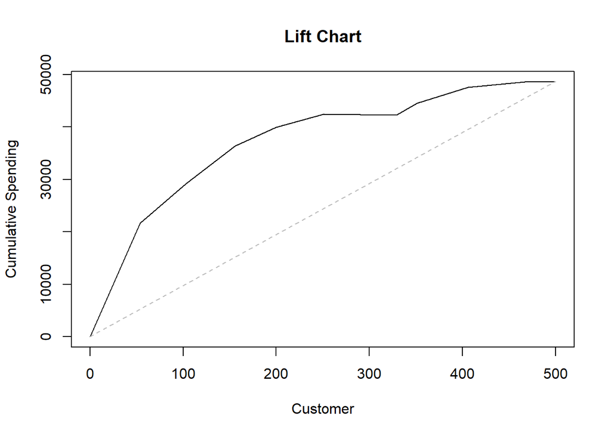

```r
Spending <- score_analysis$Spending-2
exp_spending <-score_analysis$expected_spending-2

library(gains)
gain <- gains(Spending, exp_spending)# predictions
# cumulative lift chart
options(scipen=999) # avoid scientific notation
# we will compute the gain relative to price

plot(c(0,gain$cume.pct.of.total*sum(Spending))~c(0,gain$cume.obs),
xlab="Customer", ylab="Cumulative Spending", main="Lift Chart", type="l")
# baseline
lines(c(0,sum(Spending))~c(0,dim(score_analysis)[1]), col="gray", lty=2)
```

6. Using this lift curve, estimate the gross profit that would result from mailing to the 180,000 names on the basis of your data mining models.

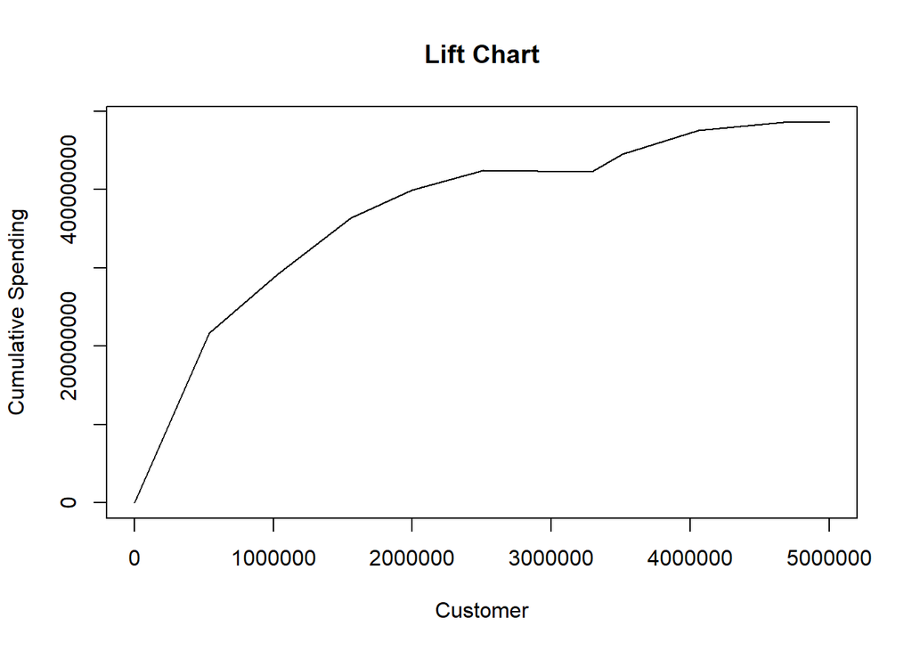

```r
factor <- 5000000/500

plot(c(0,factor * gain$cume.pct.of.total*sum(Spending))~c(0,factor*gain$cume.obs),
xlab="Customer", ylab="Cumulative Spending", main="Lift Chart", type="l")
```

```r
final_gross_profit <- approx(c(0,factor*gain$cume.obs), c(0,factor * gain$cume.pct.of.total*sum(Spending)), xout=180000)
final_gross_profit
```

```
## $x
## [1] 180000
##
## $y
## [1] 72186667
```